# Random Forest with Recursive Feature Elimination and Genetic Algorithm for Detecting Adulteration in Instant Coffee: MSC+SG+2nd Derivative Spectra

## Define the Fitness Function for GA

- This function evaluates subsets of features selected by GA using RFE with a Random Forest (RF) model.

```r
# Detect the number of cores
num_cores <- detectCores()
# Print the number of cores
print(paste("Number of cores available:", num_cores))
```

```
[1] "Number of cores available: 8"
```

```r
# Fitness Funtion
fitness_ga_rfe <- function(subset) {
  # Identify selected features based on the binary subset
  selected_features <- which(subset == 1)

  # Penalize empty subsets to avoid errors
  if (length(selected_features) == 0) return(Inf)

  # Subset the training feature matrix to selected features
  X_selected <- X_train[, selected_features]

  # Define control for RFE
  control <- rfeControl(functions = rfFuncs,  # Use Random Forest for RFE
                        method = "cv",       # Cross-validation
                        number = 10)         # 10-fold CV

  # Apply RFE to the selected subset of features
  rfe_result <- rfe(X_selected, y_train, rfeControl = control)

  # Return the negative accuracy as the fitness score (to maximize accuracy)
  return(-rfe_result$results$Accuracy[which.max(rfe_result$results$Accuracy)])
}
```

## Run the Genetic Algorithm

```r
# Set seed for reproducibility
set.seed(123)

num_features <- ncol(X_train) # Number of features
dataset_name <- "msc_sg_2d"   # Set the dataset name dynamically

# Define paths for the execution flag and GA result
flag_file <- paste0("ga_executed_flag_", dataset_name, ".RData")
result_file <- paste0("ga_result_", dataset_name, ".RData")

# Check if the result file exists
if (!file.exists(result_file)) {
  message("No result file found. Running the Genetic Algorithm (GA).")

  # Register cluster for caret to train the models in parallel
  cl <- makeCluster(6, type = "SOCK")
  suppressWarnings(suppressMessages(registerDoSNOW(cl)))

  # Register start time
  start_time <- Sys.time()

  # Run the Genetic Algorithm
  ga_result <- ga(
    type = "binary",
    fitness = fitness_ga_rfe,
    nBits = num_features,             # Number of features
    popSize = 20,                     # Population size
    maxiter = 50,                     # Maximum iterations
    run = 10,                         # Convergence stopping criterion
    names = colnames(train_data[, -ncol(train_data)]),  # Feature names
    pcrossover = 0.8,                 # Probability of crossover
    pmutation = 0.1,                  # Probability of mutation
    maxFitness = -0.9,                # Stop when fitness reaches target
    parallel = TRUE,                  # Enable parallel processing
    monitor = gaMonitor,              # Track progress
    seed = 123                        # Reproducibility
  )

  # Stop the cluster
  stopCluster(cl)

  # Register end time
  end_time <- Sys.time()
  print(paste('Time to run the GA model:', end_time - start_time))

  # Save the GA result and execution flag
  ga_executed <- TRUE
  save(ga_executed, ga_result, file = result_file)  # Save both flag and results

  message("GA execution completed and results saved.")

} else {
  # Load previously saved results
  message("Result file found. Loading saved GA results.")
  load(result_file)
  message(paste("GA already executed for dataset:", dataset_name))
}
```

```
Result file found. Loading saved GA results.
```

```
GA already executed for dataset: msc_sg_2d
```

## Visualization Plot

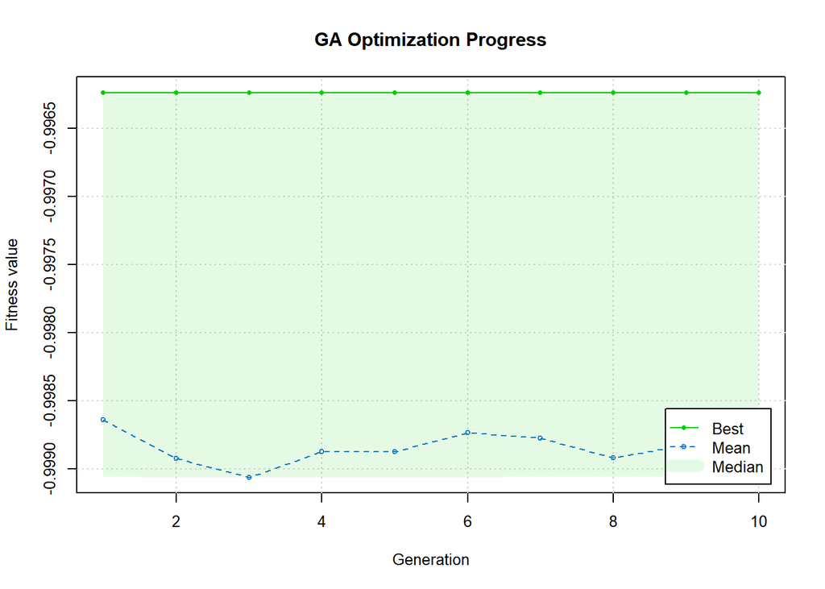

```r
par (cex = 0.8)
plot(ga_result, main = "GA Optimization Progress")
```

```r
par(cex = 1)
```

## Analyze GA results

```r
summary(ga_result)
```

```
── Genetic Algorithm ───────────────────

GA settings:
Type                  =  binary
Population size       =  20
Number of generations =  50
Elitism               =  1
Crossover probability =  0.8
Mutation probability  =  0.1

GA results:
Iterations             = 10
Fitness function value = -0.9962352
Solution =
     X935.609985 X939.059998 X942.52002 X945.97998 X949.429993 X952.890015
[1,]           1           0          0          0           0           0
     X956.349976 X959.809998 X963.27002 X966.72998  ...  X1716.650024
[1,]           0           1          1          1                  0
     X1720.22998
[1,]           1
```

## Post-Selection

```r
# Get the best feature indices selected by GA
best_features <- which(ga_result@solution == 1)

# Remove indices beyond available columns
best_features <- best_features[best_features <= ncol(train_data)]

# Get selected feature names
selected_feature_names <- colnames(train_data)[best_features]

print(selected_feature_names)
```

```
  [1] "X935.609985"  "X959.809998"  "X963.27002"   "X966.72998"   "X970.190002"
  [6] "X977.109985"  "X984.039978"  "X990.969971"  "X994.429993"  "X1001.369995"
 [11] "X1004.830017" "X1008.299988" "X1025.650024" "X1029.119995" "X1032.589966"
 [16] "X1039.530029" "X1043"        "X1049.949951" "X1056.900024" "X1063.849976"
 [21] "X1074.290039" "X1077.76001"  "X1081.23999"  "X1084.719971" "X1088.199951"
 [26] "X1098.650024" "X1102.130005" "X1109.099976" "X1126.52002"  "X1136.98999"
 [31] "X1147.449951" "X1154.430054" "X1157.930054" "X1161.420044" "X1168.400024"
 [36] "X1171.900024" "X1185.880005" "X1189.369995" "X1196.369995" "X1203.369995"
 [41] "X1217.369995" "X1224.369995" "X1231.380005" "X1234.880005" "X1241.890015"
 [46] "X1266.439941" "X1283.98999"  "X1291.02002"  "X1294.530029" "X1308.589966"
 [51] "X1315.619995" "X1319.140015" "X1340.26001"  "X1347.300049" "X1361.390015"
 [56] "X1364.920044" "X1368.439941" "X1371.969971" "X1375.5"      "X1382.550049"
 [61] "X1396.670044" "X1400.199951" "X1407.26001"  "X1414.319946" "X1424.920044"
 [66] "X1428.459961" "X1435.530029" "X1439.069946" "X1442.599976" "X1449.680054"
 [71] "X1467.380005" "X1470.920044" "X1478.01001"  "X1485.089966" "X1488.640015"
 [76] "X1492.180054" "X1495.72998"  "X1499.27002"  "X1513.459961" "X1517.01001"
 [81] "X1520.560059" "X1531.209961" "X1534.76001"  "X1545.420044" "X1570.310059"
 [86] "X1580.98999"  "X1588.109985" "X1595.22998"  "X1605.920044" "X1609.47998"
 [91] "X1616.609985" "X1620.170044" "X1627.310059" "X1630.869995" "X1634.439941"
 [96] "X1638.01001"  "X1641.579956" "X1648.709961" "X1666.569946" "X1670.140015"
[101] "X1688.02002"  "X1691.589966" "X1709.48999"  "X1713.069946" "X1720.22998"
```

```r
print(paste('The number of selected variables are', length(selected_feature_names)))
```

```
[1] "The number of selected variables are 105"
```

```r
n_selected <- as.numeric(length(selected_feature_names))
```

## Create a Data frame with the Selected Features

```r
# Subset the training and test data using the selected features
X_train_selected <- X_train[, selected_feature_names, drop = FALSE]
X_test_selected <- X_test[, selected_feature_names, drop = FALSE]

# Keep y_train and y_test as-is
y_train_selected <- y_train
y_test_selected <- y_test


#Merge data_frame
train_merged <- cbind(X_train_selected, binary_class = y_train_selected)
test_merged <- cbind(X_test_selected, binary_class = y_test_selected)

dim(train_merged)
```

```
[1] 1065  106
```

```r
dim(test_merged)
```

```
[1] 411 106
```

```r
table(train_merged$binary_class)
```

```
 adulterated pure_arabica
        1017           48
```

```r
table(test_merged$binary_class)
```

```
 adulterated pure_arabica
         384           27
```

## Create a Data frame with the Selected Features for SMOTE Data

```r
X_train_selected_smote <- X_train_smote[,selected_feature_names, drop = FALSE]
X_test_selected_smote <- X_test[, selected_feature_names, drop = FALSE]

# Keep y_train and y_test as-is
y_train_selected_smote <- y_train
y_test_selected_smote <- y_test

#Merge data_frame
train_merged_smote <- cbind(X_train_selected_smote, binary_class = smote_data$binary_class)
test_merged_smote <- cbind(X_test_selected_smote, binary_class = y_test_selected_smote)

dim(train_merged_smote)
```

```
[1] 1872  106
```

```r
dim(test_merged_smote)
```

```
[1] 411 106
```

```r
table(train_merged_smote$binary_class)
```

```
 adulterated pure_arabica
         912          960
```

```r
table(test_merged_smote$binary_class)
```

```
 adulterated pure_arabica
         384           27
```

## Check correlations by HeatMaps

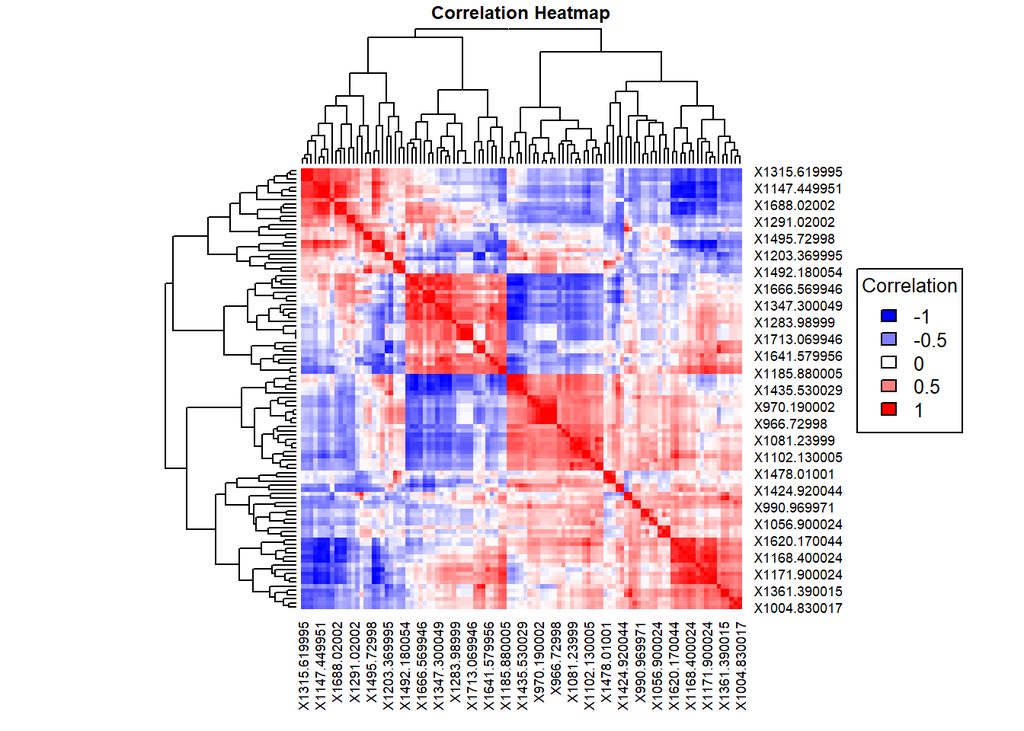

```r
# Calculate the correlation matrix

#Imbalanced Data

#Calculate correlations
corr <- cor(train_merged[, -(n_selected+1)])

# Create a heat map
par(cex.main = 0.6)
heatmap(corr, symm = TRUE,
        col = colorRampPalette(c("blue", "white", "red"))(50),
        main = "Correlation Heatmap")

# Add legend

legend("right",
       legend = seq(-1, 1, by = 0.5),  # Correlation range
       fill = colorRampPalette(c("blue", "white", "red"))(5),
       title = "Correlation", cex = 0.8)
```

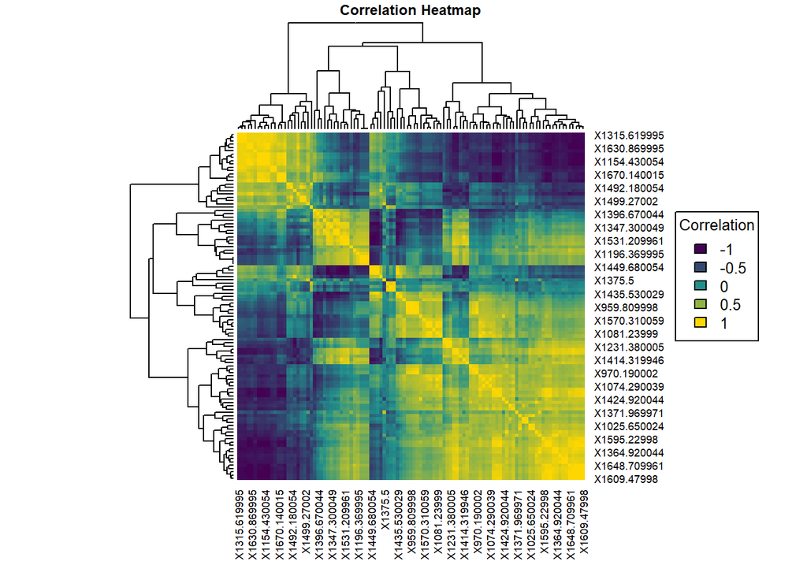

```r
# SMOTE Data
par(cex.main = 0.6)
corr <- cor(train_merged_smote[, -(n_selected+1)])
# Create heat map
heatmap(corr, symm = TRUE,
        col = colorRampPalette(c("#440154", "#21908C", "gold"))(50),
        main = 'Correlation Heatmap',cex.main = 0.6)

# Add legend
legend("right",
       legend = seq(-1, 1, by = 0.5),  # Correlation range
       fill = colorRampPalette(c("#440154", "#21908C", "gold"))(5),
       title = "Correlation",
       cex = 0.8)
```

- The correlation heat maps reveal that some variables remain highly correlated. To address this issue and mitigate multicollinearity, we will employ Principal Component Analysis (PCA)

## PreProcess by PCA, Centering and Scaling Data

```r
# Imbalanced Data
pca_Preprocess <- preProcess(train_merged, method = c("center", "scale", "pca"))
train_mergedPreprocessed <- predict(pca_Preprocess, train_merged) # train data
test_mergedPreprocessed <- predict(pca_Preprocess,test_merged) # apply on test data

# SMOTE Data
pca_Preprocess_smote <- preProcess(train_merged_smote,method = c("center", "scale", "pca"))
train_merged_smote_Preprocessed <- predict(pca_Preprocess_smote,train_merged_smote)
test_merged_smote_Preprocessed <- predict(pca_Preprocess_smote,test_merged_smote)

# Check dimensions of the preprocessed data to ensure consistency

dim(train_mergedPreprocessed)
```

```
[1] 1065   18
```

```r
dim(test_mergedPreprocessed)
```

```
[1] 411  18
```

```r
dim(train_merged_smote_Preprocessed)
```

```
[1] 1872   12
```

```r
dim(test_merged_smote_Preprocessed)
```

```
[1] 411  12
```

## Train Models

### Random Forest

- We will train a Random Forest model using sparse variables selected by the RFE and GA algorithms, further reduced through Principal Component Analysis (PCA).

## Set Up Training Parameters

```r
# Set random seed for reproducibility

set.seed (123)

# Set up the training control(10 folds 10 times cross_validation)
control <- trainControl(method = "repeatedcv", number = 10, repeats = 10,
                        classProbs = TRUE, savePredictions = "final",
                        summaryFunction = multiClassSummary,
                        selectionFunction = 'oneSE', allowParallel = TRUE)

# OneSE rule will be used to select simplest yet optimal model within the 'best model'
```

```r
#Set the metric as accuracy
metric<-"Accuracy"
```

```r
# Hyperparameter Tuning
# We will use tuneLength to automatically determine the optimal parameters (mtry)
#The number of trees will be set to 500 (default)
```

## Train the Models

```r
#Register cluster for caret to train the models in parallel
cl<-makeCluster(6,type = "SOCK")
suppressWarnings(suppressMessages(
  registerDoSNOW(cl)))

# Start_time
start_time<-Sys.time()

#Train the model using cross-validation (10 folds, 10 times)
fit_rf_msc_sg_2d<-train(y = train_mergedPreprocessed[,1],
                         x = train_mergedPreprocessed[,-1],
                         method = 'rf', tuneLength =  10,
                         trControl = control,
                         metric = 'Accuracy') #unmodified data
#End_time
end_time<-Sys.time()

model_training_time<-end_time-start_time

stopCluster(cl) # Stop the parallel run cluster

print(model_training_time)
```

```
Time difference of 1.902845 mins
```

```r
#Register cluster for caret to train the models in parallel
cl<-makeCluster(6,type = "SOCK")
suppressWarnings(suppressMessages(
  registerDoSNOW(cl)))

# Start_time
start_time<-Sys.time()
fit_rf_smote_msc_sg_2d <- train(y = train_merged_smote_Preprocessed[,1],
                         x = train_merged_smote_Preprocessed[,-1],
                         method = 'rf', tuneLength = 10,
                         trControl = control,
                         metric = 'Accuracy') # SMOTE data

#End_time
end_time<-Sys.time()

model_training_time<-end_time-start_time

stopCluster(cl) # Stop the parallel run cluster

print(model_training_time)
```

```
Time difference of 2.499985 mins
```

```r
# Display model results for imbalanced data
print(fit_rf_msc_sg_2d)
```

```
Random Forest

1065 samples
  17 predictor
   2 classes: 'adulterated', 'pure_arabica'

No pre-processing
Resampling: Cross-Validated (10 fold, repeated 10 times)
Summary of sample sizes: 958, 959, 958, 960, 958, 959, ...
Resampling results across tuning parameters:

  mtry  logLoss     AUC        prAUC      Accuracy   Kappa      F1
   2    0.03374589  0.9999804  0.7999720  0.9954919  0.9389719  0.9976547
   3    0.02602824  0.9999804  0.7367386  0.9970895  0.9619949  0.9984830
   5    0.01896580  0.9999606  0.6348581  0.9975577  0.9698647  0.9987235
   7    0.01575106  0.9999361  0.5647060  0.9979351  0.9750215  0.9989196
   8    0.01469602  0.9999361  0.5331920  0.9979342  0.9748197  0.9989196
  10    0.01360896  0.9999361  0.4966999  0.9978425  0.9752017  0.9988689
  12    0.01306566  0.9998675  0.4681889  0.9975586  0.9706666  0.9987221
  13    0.01305361  0.9997984  0.4507982  0.9978416  0.9747277  0.9988694
  15    0.01316442  0.9996606  0.4268103  0.9968074  0.9624206  0.9983275
  17    0.01457767  0.9994448  0.3876458  0.9956771  0.9489642  0.9977353
  Sensitivity  Specificity  Pos_Pred_Value  Neg_Pred_Value  Precision
  1.0000000    0.9000       0.9953406       1.0000000       0.9953406
  0.9996069    0.9435       0.9973777       0.9933333       0.9973777
  0.9991157    0.9645       0.9983438       0.9840000       0.9983438
  0.9990177    0.9750       0.9988321       0.9823333       0.9988321
  0.9991157    0.9730       0.9987341       0.9840000       0.9987341
  0.9988206    0.9775       0.9989282       0.9794762       0.9989282
  0.9988206    0.9710       0.9986379       0.9794762       0.9986379
  0.9989187    0.9755       0.9988321       0.9811429       0.9988321
  0.9982304    0.9670       0.9984437       0.9694762       0.9984437
  0.9973452    0.9595       0.9981506       0.9538095       0.9981506
  Recall     Detection_Rate  Balanced_Accuracy
  1.0000000  0.9549423       0.9500000
  0.9996069  0.9545676       0.9715534
  0.9991157  0.9540976       0.9818079
  0.9990177  0.9540042       0.9870088
  0.9991157  0.9540976       0.9860579
  0.9988206  0.9538164       0.9881603
  0.9988206  0.9538164       0.9849103
  0.9989187  0.9539098       0.9872093
  0.9982304  0.9532521       0.9826152
  0.9973452  0.9524066       0.9784226

Accuracy was used to select the optimal model using  the one SE rule.
The final value used for the model was mtry = 5.
```

```r
# Display results for data balanced by SMOTE
print(fit_rf_smote_msc_sg_2d)
```

```
Random Forest

1872 samples
  11 predictor
   2 classes: 'adulterated', 'pure_arabica'

No pre-processing
Resampling: Cross-Validated (10 fold, repeated 10 times)
Summary of sample sizes: 1685, 1684, 1685, 1685, 1685, 1685, ...
Resampling results across tuning parameters:

  mtry  logLoss      AUC  prAUC        Accuracy   Kappa      F1
   2    0.011761171  1    0.808551844  1.0000000  1.0000000  1.0000000
   3    0.006073278  1    0.624696409  1.0000000  1.0000000  1.0000000
   4    0.003624231  1    0.434241345  1.0000000  1.0000000  1.0000000
   5    0.002482117  1    0.273783171  0.9998396  0.9996788  0.9998343
   6    0.001907439  1    0.173510213  0.9997861  0.9995717  0.9997784
   7    0.001612357  1    0.104268370  0.9996791  0.9993575  0.9996667
   8    0.001482397  1    0.060066815  0.9996791  0.9993575  0.9996667
   9    0.001477703  1    0.033349384  0.9996791  0.9993575  0.9996667
  10    0.001584861  1    0.016645664  0.9996791  0.9993575  0.9996667
  11    0.002162616  1    0.009570493  0.9996791  0.9993575  0.9996667
  Sensitivity  Specificity  Pos_Pred_Value  Neg_Pred_Value  Precision
  1.0000000    1            1               1.0000000       1
  1.0000000    1            1               1.0000000       1
  1.0000000    1            1               1.0000000       1
  0.9996703    1            1               0.9996907       1
  0.9995604    1            1               0.9995897       1
  0.9993407    1            1               0.9993878       1
  0.9993407    1            1               0.9993878       1
  0.9993407    1            1               0.9993878       1
  0.9993407    1            1               0.9993878       1
  0.9993407    1            1               0.9993878       1
  Recall     Detection_Rate  Balanced_Accuracy
  1.0000000  0.4871772       1.0000000
  1.0000000  0.4871772       1.0000000
  1.0000000  0.4871772       1.0000000
  0.9996703  0.4870167       0.9998352
  0.9995604  0.4869632       0.9997802
  0.9993407  0.4868563       0.9996703
  0.9993407  0.4868563       0.9996703
  0.9993407  0.4868563       0.9996703
  0.9993407  0.4868563       0.9996703
  0.9993407  0.4868563       0.9996703

Accuracy was used to select the optimal model using  the one SE rule.
The final value used for the model was mtry = 2.
```

## Save the models for future use

```r
saveRDS(fit_rf_msc_sg_2d, "fit_rf_msc_sg_2d.rds")
saveRDS(fit_rf_smote_msc_sg_2d, "fit_rf_smote_msc_sg_2d.rds")
```

## Plot the cross-validation results —-> Model selection

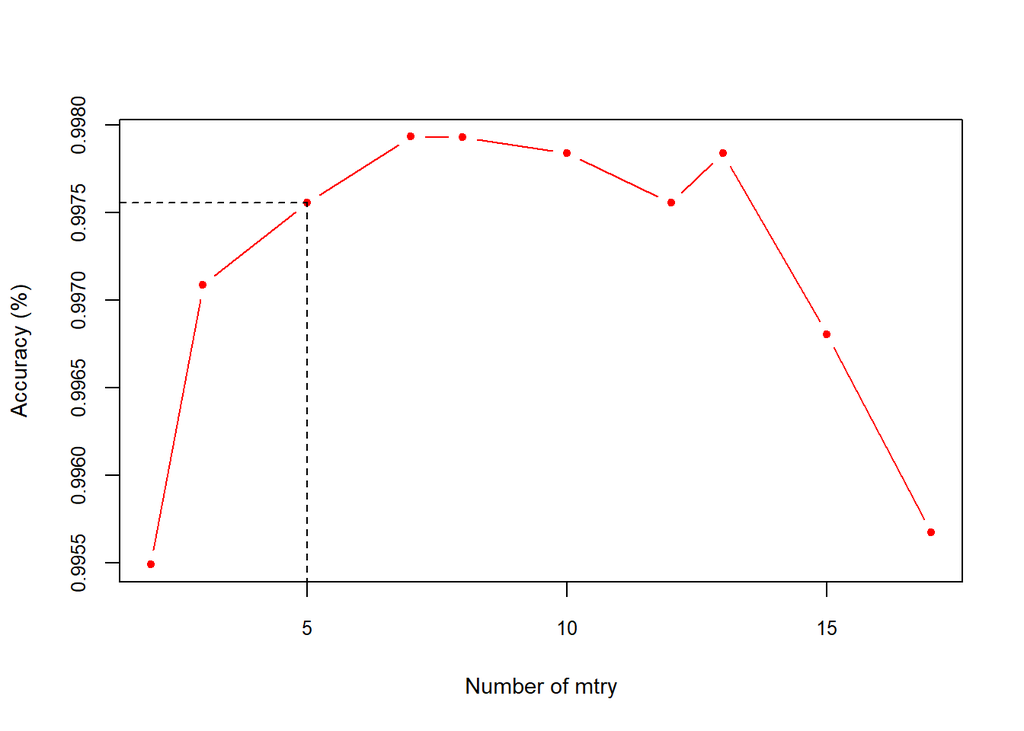

```r
# Imbalanced Data
mtry_data <- fit_rf_msc_sg_2d$results
best_mtry = fit_rf_msc_sg_2d$bestTune$mtry
y_Acc = mtry_data$Accuracy[mtry_data$mtry == best_mtry]
plot(mtry_data$mtry,mtry_data$Accuracy, type = "b",col = "red",pch = 20,cex.axis = 0.8,
     xlab = "Number of mtry", ylab = "Accuracy (%)",cex.lab = 0.9)
# Add line from x-axis to the specific point
segments(x0 = best_mtry, y0 = 0, x1 = best_mtry, y1 = y_Acc, col = "black", lty = 2)

# Add line from y-axis to the specific point
segments(x0 = 0, y0 = y_Acc, x1 = best_mtry, y1 = y_Acc, col = "black", lty = 2)
```

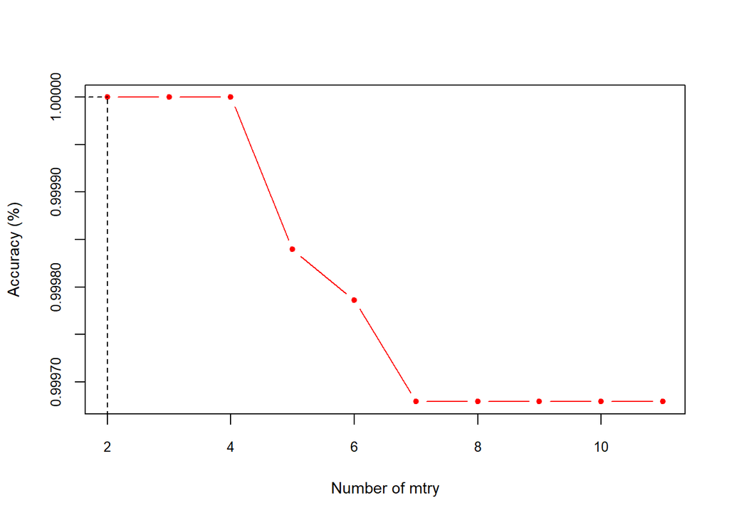

```r
# Balanced Data

mtry_data <- fit_rf_smote_msc_sg_2d$results
best_mtry = fit_rf_smote_msc_sg_2d$bestTune$mtry
y_Acc = mtry_data$Accuracy[mtry_data$mtry == best_mtry]
plot(mtry_data$mtry,mtry_data$Accuracy, type = "b",col = "red",pch = 20,cex.axis = 0.8,
     xlab = "Number of mtry", ylab = "Accuracy (%)",cex.lab = 0.9)
# Add line from x-axis to the specific point
segments(x0 = best_mtry, y0 = 0, x1 = best_mtry, y1 = y_Acc, col = "black", lty = 2)

# Add line from y-axis to the specific point
segments(x0 = 0, y0 = y_Acc, x1 = best_mtry, y1 = y_Acc, col = "black", lty = 2)
```

## Display the cross-validation results

```r
print(paste('The optimal parametrers for training the rf model are mtry value of',
            fit_rf_msc_sg_2d$bestTune$mtry)) # unmodified data
```

```
[1] "The optimal parametrers for training the rf model are mtry value of 5"
```

```r
print(paste('The optimal parametrers for training the rf model are mtry value of',
            fit_rf_smote_msc_sg_2d$bestTune$mtry)) # SMOTE data
```

```
[1] "The optimal parametrers for training the rf model are mtry value of 2"
```

## Display CV results in Tables

```r
# Imbalanced data
knitr::kable(fit_rf_msc_sg_2d$results)
```

| mtry | logLoss | AUC | prAUC | Accuracy | Kappa | F1 | Sensitivity | Specificity | Pos_Pred_Value | Neg_Pred_Value | Precision | Recall | Detection_Rate | Balanced_Accuracy | logLossSD | AUCSD | prAUCSD | AccuracySD | KappaSD | F1SD | SensitivitySD | SpecificitySD | Pos_Pred_ValueSD | Neg_Pred_ValueSD | PrecisionSD | RecallSD | Detection_RateSD | Balanced_AccuracySD |
| --- | --- | --- | --- | --- | --- | --- | --- | --- | --- | --- | --- | --- | --- | --- | --- | --- | --- | --- | --- | --- | --- | --- | --- | --- | --- | --- | --- | --- |
| 2 | 0.0337459 | 0.9999804 | 0.7999720 | 0.9954919 | 0.9389719 | 0.9976547 | 1.0000000 | 0.9000 | 0.9953406 | 1.0000000 | 0.9953406 | 1.0000000 | 0.9549423 | 0.9500000 | 0.0046714 | 0.0001961 | 0.0208147 | 0.0061932 | 0.0880867 | 0.0032173 | 0.0000000 | 0.1388990 | 0.0063836 | 0.0000000 | 0.0063836 | 0.0000000 | 0.0036305 | 0.0694495 |
| 3 | 0.0260282 | 0.9999804 | 0.7367386 | 0.9970895 | 0.9619949 | 0.9984830 | 0.9996069 | 0.9435 | 0.9973777 | 0.9933333 | 0.9973777 | 0.9996069 | 0.9545676 | 0.9715534 | 0.0048107 | 0.0001961 | 0.0254261 | 0.0051224 | 0.0704356 | 0.0026658 | 0.0019356 | 0.1118384 | 0.0051343 | 0.0328244 | 0.0051343 | 0.0019356 | 0.0042348 | 0.0558272 |
| 5 | 0.0189658 | 0.9999606 | 0.6348581 | 0.9975577 | 0.9698647 | 0.9987235 | 0.9991157 | 0.9645 | 0.9983438 | 0.9840000 | 0.9983438 | 0.9991157 | 0.9540976 | 0.9818079 | 0.0049562 | 0.0002773 | 0.0319399 | 0.0045548 | 0.0593496 | 0.0023781 | 0.0028261 | 0.0868340 | 0.0039284 | 0.0513521 | 0.0039284 | 0.0028261 | 0.0044787 | 0.0433715 |
| 7 | 0.0157511 | 0.9999361 | 0.5647060 | 0.9979351 | 0.9750215 | 0.9989196 | 0.9990177 | 0.9750 | 0.9988321 | 0.9823333 | 0.9988321 | 0.9990177 | 0.9540042 | 0.9870088 | 0.0051073 | 0.0003674 | 0.0327390 | 0.0043437 | 0.0560237 | 0.0022696 | 0.0029619 | 0.0770347 | 0.0034653 | 0.0534878 | 0.0034653 | 0.0029619 | 0.0045922 | 0.0385134 |
| 8 | 0.0146960 | 0.9999361 | 0.5331920 | 0.9979342 | 0.9748197 | 0.9989196 | 0.9991157 | 0.9730 | 0.9987341 | 0.9840000 | 0.9987341 | 0.9991157 | 0.9540976 | 0.9860579 | 0.0053285 | 0.0003674 | 0.0312533 | 0.0043452 | 0.0563169 | 0.0022696 | 0.0028261 | 0.0789515 | 0.0035690 | 0.0513521 | 0.0035690 | 0.0028261 | 0.0044787 | 0.0394737 |
| 10 | 0.0136090 | 0.9999361 | 0.4966999 | 0.9978425 | 0.9752017 | 0.9988689 | 0.9988206 | 0.9775 | 0.9989282 | 0.9794762 | 0.9989282 | 0.9988206 | 0.9538164 | 0.9881603 | 0.0058012 | 0.0003674 | 0.0317321 | 0.0043936 | 0.0500054 | 0.0023060 | 0.0035048 | 0.0645008 | 0.0030640 | 0.0597938 | 0.0030640 | 0.0035048 | 0.0049994 | 0.0322438 |
| 12 | 0.0130657 | 0.9998675 | 0.4681889 | 0.9975586 | 0.9706666 | 0.9987221 | 0.9988206 | 0.9710 | 0.9986379 | 0.9794762 | 0.9986379 | 0.9988206 | 0.9538164 | 0.9849103 | 0.0065318 | 0.0004976 | 0.0326150 | 0.0049325 | 0.0623885 | 0.0025801 | 0.0035048 | 0.0856290 | 0.0039141 | 0.0597938 | 0.0039141 | 0.0035048 | 0.0049994 | 0.0427642 |
| 13 | 0.0130536 | 0.9997984 | 0.4507982 | 0.9978416 | 0.9747277 | 0.9988694 | 0.9989187 | 0.9755 | 0.9988321 | 0.9811429 | 0.9988321 | 0.9989187 | 0.9539098 | 0.9872093 | 0.0069895 | 0.0006713 | 0.0382721 | 0.0045951 | 0.0540970 | 0.0024081 | 0.0033966 | 0.0726466 | 0.0034653 | 0.0579742 | 0.0034653 | 0.0033966 | 0.0048990 | 0.0363151 |
| 15 | 0.0131644 | 0.9996606 | 0.4268103 | 0.9968074 | 0.9624206 | 0.9983275 | 0.9982304 | 0.9670 | 0.9984437 | 0.9694762 | 0.9984437 | 0.9982304 | 0.9532521 | 0.9826152 | 0.0082855 | 0.0009807 | 0.0459528 | 0.0053831 | 0.0664884 | 0.0028181 | 0.0042815 | 0.0888251 | 0.0040807 | 0.0728309 | 0.0040807 | 0.0042815 | 0.0054030 | 0.0442433 |
| 17 | 0.0145777 | 0.9994448 | 0.3876458 | 0.9956771 | 0.9489642 | 0.9977353 | 0.9973452 | 0.9595 | 0.9981506 | 0.9538095 | 0.9981506 | 0.9973452 | 0.9524066 | 0.9784226 | 0.0114922 | 0.0012809 | 0.0589872 | 0.0055784 | 0.0692649 | 0.0029203 | 0.0048096 | 0.0960574 | 0.0043055 | 0.0828402 | 0.0043055 | 0.0048096 | 0.0057666 | 0.0476250 |

```r
# Select the best results row
selected_row <- fit_rf_msc_sg_2d$results %>%
  filter(mtry==fit_rf_msc_sg_2d$bestTune$mtry)

knitr::kable(selected_row)
```

| mtry | logLoss | AUC | prAUC | Accuracy | Kappa | F1 | Sensitivity | Specificity | Pos_Pred_Value | Neg_Pred_Value | Precision | Recall | Detection_Rate | Balanced_Accuracy | logLossSD | AUCSD | prAUCSD | AccuracySD | KappaSD | F1SD | SensitivitySD | SpecificitySD | Pos_Pred_ValueSD | Neg_Pred_ValueSD | PrecisionSD | RecallSD | Detection_RateSD | Balanced_AccuracySD |
| --- | --- | --- | --- | --- | --- | --- | --- | --- | --- | --- | --- | --- | --- | --- | --- | --- | --- | --- | --- | --- | --- | --- | --- | --- | --- | --- | --- | --- |
| 5 | 0.0189658 | 0.9999606 | 0.6348581 | 0.9975577 | 0.9698647 | 0.9987235 | 0.9991157 | 0.9645 | 0.9983438 | 0.984 | 0.9983438 | 0.9991157 | 0.9540976 | 0.9818079 | 0.0049562 | 0.0002773 | 0.0319399 | 0.0045548 | 0.0593496 | 0.0023781 | 0.0028261 | 0.086834 | 0.0039284 | 0.0513521 | 0.0039284 | 0.0028261 | 0.0044787 | 0.0433715 |

```r
# SMOTE Data
knitr::kable(fit_rf_smote_msc_sg_2d$results)
```

| mtry | logLoss | AUC | prAUC | Accuracy | Kappa | F1 | Sensitivity | Specificity | Pos_Pred_Value | Neg_Pred_Value | Precision | Recall | Detection_Rate | Balanced_Accuracy | logLossSD | AUCSD | prAUCSD | AccuracySD | KappaSD | F1SD | SensitivitySD | SpecificitySD | Pos_Pred_ValueSD | Neg_Pred_ValueSD | PrecisionSD | RecallSD | Detection_RateSD | Balanced_AccuracySD |
| --- | --- | --- | --- | --- | --- | --- | --- | --- | --- | --- | --- | --- | --- | --- | --- | --- | --- | --- | --- | --- | --- | --- | --- | --- | --- | --- | --- | --- |
| 2 | 0.0117612 | 1 | 0.8085518 | 1.0000000 | 1.0000000 | 1.0000000 | 1.0000000 | 1 | 1 | 1.0000000 | 1 | 1.0000000 | 0.4871772 | 1.0000000 | 0.0016677 | 0 | 0.0337316 | 0.0000000 | 0.0000000 | 0.0000000 | 0.0000000 | 0 | 0 | 0.0000000 | 0 | 0.0000000 | 0.0010978 | 0.0000000 |
| 3 | 0.0060733 | 1 | 0.6246964 | 1.0000000 | 1.0000000 | 1.0000000 | 1.0000000 | 1 | 1 | 1.0000000 | 1 | 1.0000000 | 0.4871772 | 1.0000000 | 0.0014029 | 0 | 0.0423529 | 0.0000000 | 0.0000000 | 0.0000000 | 0.0000000 | 0 | 0 | 0.0000000 | 0 | 0.0000000 | 0.0010978 | 0.0000000 |
| 4 | 0.0036242 | 1 | 0.4342413 | 1.0000000 | 1.0000000 | 1.0000000 | 1.0000000 | 1 | 1 | 1.0000000 | 1 | 1.0000000 | 0.4871772 | 1.0000000 | 0.0013455 | 0 | 0.0408039 | 0.0000000 | 0.0000000 | 0.0000000 | 0.0000000 | 0 | 0 | 0.0000000 | 0 | 0.0000000 | 0.0010978 | 0.0000000 |
| 5 | 0.0024821 | 1 | 0.2737832 | 0.9998396 | 0.9996788 | 0.9998343 | 0.9996703 | 1 | 1 | 0.9996907 | 1 | 0.9996703 | 0.4870167 | 0.9998352 | 0.0014965 | 0 | 0.0409529 | 0.0009168 | 0.0018355 | 0.0009472 | 0.0018840 | 0 | 0 | 0.0017675 | 0 | 0.0018840 | 0.0014909 | 0.0009420 |
| 6 | 0.0019074 | 1 | 0.1735102 | 0.9997861 | 0.9995717 | 0.9997784 | 0.9995604 | 1 | 1 | 0.9995897 | 1 | 0.9995604 | 0.4869632 | 0.9997802 | 0.0016528 | 0 | 0.0330704 | 0.0012988 | 0.0026007 | 0.0013469 | 0.0026690 | 0 | 0 | 0.0024868 | 0 | 0.0026690 | 0.0017686 | 0.0013345 |
| 7 | 0.0016124 | 1 | 0.1042684 | 0.9996791 | 0.9993575 | 0.9996667 | 0.9993407 | 1 | 1 | 0.9993878 | 1 | 0.9993407 | 0.4868563 | 0.9996703 | 0.0019083 | 0 | 0.0244437 | 0.0018337 | 0.0036720 | 0.0019050 | 0.0037681 | 0 | 0 | 0.0034989 | 0 | 0.0037681 | 0.0022184 | 0.0018840 |
| 8 | 0.0014824 | 1 | 0.0600668 | 0.9996791 | 0.9993575 | 0.9996667 | 0.9993407 | 1 | 1 | 0.9993878 | 1 | 0.9993407 | 0.4868563 | 0.9996703 | 0.0021405 | 0 | 0.0180346 | 0.0018337 | 0.0036720 | 0.0019050 | 0.0037681 | 0 | 0 | 0.0034989 | 0 | 0.0037681 | 0.0022184 | 0.0018840 |
| 9 | 0.0014777 | 1 | 0.0333494 | 0.9996791 | 0.9993575 | 0.9996667 | 0.9993407 | 1 | 1 | 0.9993878 | 1 | 0.9993407 | 0.4868563 | 0.9996703 | 0.0026962 | 0 | 0.0141032 | 0.0018337 | 0.0036720 | 0.0019050 | 0.0037681 | 0 | 0 | 0.0034989 | 0 | 0.0037681 | 0.0022184 | 0.0018840 |
| 10 | 0.0015849 | 1 | 0.0166457 | 0.9996791 | 0.9993575 | 0.9996667 | 0.9993407 | 1 | 1 | 0.9993878 | 1 | 0.9993407 | 0.4868563 | 0.9996703 | 0.0034999 | 0 | 0.0096410 | 0.0018337 | 0.0036720 | 0.0019050 | 0.0037681 | 0 | 0 | 0.0034989 | 0 | 0.0037681 | 0.0022184 | 0.0018840 |
| 11 | 0.0021626 | 1 | 0.0095705 | 0.9996791 | 0.9993575 | 0.9996667 | 0.9993407 | 1 | 1 | 0.9993878 | 1 | 0.9993407 | 0.4868563 | 0.9996703 | 0.0067030 | 0 | 0.0072141 | 0.0018337 | 0.0036720 | 0.0019050 | 0.0037681 | 0 | 0 | 0.0034989 | 0 | 0.0037681 | 0.0022184 | 0.0018840 |

```r
# Select the best results row
selected_row_smote <- fit_rf_smote_msc_sg_2d$results %>%
  filter(mtry== fit_rf_smote_msc_sg_2d$bestTune$mtry)

knitr::kable(selected_row_smote)
```

| mtry | logLoss | AUC | prAUC | Accuracy | Kappa | F1 | Sensitivity | Specificity | Pos_Pred_Value | Neg_Pred_Value | Precision | Recall | Detection_Rate | Balanced_Accuracy | logLossSD | AUCSD | prAUCSD | AccuracySD | KappaSD | F1SD | SensitivitySD | SpecificitySD | Pos_Pred_ValueSD | Neg_Pred_ValueSD | PrecisionSD | RecallSD | Detection_RateSD | Balanced_AccuracySD |
| --- | --- | --- | --- | --- | --- | --- | --- | --- | --- | --- | --- | --- | --- | --- | --- | --- | --- | --- | --- | --- | --- | --- | --- | --- | --- | --- | --- | --- |
| 2 | 0.0117612 | 1 | 0.8085518 | 1 | 1 | 1 | 1 | 1 | 1 | 1 | 1 | 1 | 0.4871772 | 1 | 0.0016677 | 0 | 0.0337316 | 0 | 0 | 0 | 0 | 0 | 0 | 0 | 0 | 0 | 0.0010978 | 0 |

## Confusion matrix for the training data

```r
confusionMatrix(fit_rf_msc_sg_2d$pred$pred,fit_rf_msc_sg_2d$pred$obs) # unmodified data
```

```
Confusion Matrix and Statistics

              Reference
Prediction     adulterated pure_arabica
  adulterated        10161           17
  pure_arabica           9          463

               Accuracy : 0.9976
                 95% CI : (0.9964, 0.9984)
    No Information Rate : 0.9549
    P-Value [Acc > NIR] : <2e-16

                  Kappa : 0.9714

 Mcnemar's Test P-Value : 0.1698

            Sensitivity : 0.9991
            Specificity : 0.9646
         Pos Pred Value : 0.9983
         Neg Pred Value : 0.9809
             Prevalence : 0.9549
         Detection Rate : 0.9541
   Detection Prevalence : 0.9557
      Balanced Accuracy : 0.9818

       'Positive' Class : adulterated
```

```r
confusionMatrix(fit_rf_smote_msc_sg_2d$pred$pred,fit_rf_smote_msc_sg_2d$pred$obs) # SMOTE data
```

```
Confusion Matrix and Statistics

              Reference
Prediction     adulterated pure_arabica
  adulterated         9120            0
  pure_arabica           0         9600

               Accuracy : 1
                 95% CI : (0.9998, 1)
    No Information Rate : 0.5128
    P-Value [Acc > NIR] : < 2.2e-16

                  Kappa : 1

 Mcnemar's Test P-Value : NA

            Sensitivity : 1.0000
            Specificity : 1.0000
         Pos Pred Value : 1.0000
         Neg Pred Value : 1.0000
             Prevalence : 0.4872
         Detection Rate : 0.4872
   Detection Prevalence : 0.4872
      Balanced Accuracy : 1.0000

       'Positive' Class : adulterated
```

## Test the model performance on test data for unbalanced trained data

```r
# Predict on the test set
set.seed(123)

test_rf_unmodified <- predict(fit_rf_msc_sg_2d,newdata=test_mergedPreprocessed)

# Get the confusion matrix
test_rf_unmodified_CMtrx <- confusionMatrix(test_rf_unmodified,
                                             test_mergedPreprocessed$binary_class)
test_rf_unmodified_CMtrx
```

```
Confusion Matrix and Statistics

              Reference
Prediction     adulterated pure_arabica
  adulterated          383            2
  pure_arabica           1           25

               Accuracy : 0.9927
                 95% CI : (0.9788, 0.9985)
    No Information Rate : 0.9343
    P-Value [Acc > NIR] : 3.3e-09

                  Kappa : 0.9395

 Mcnemar's Test P-Value : 1

            Sensitivity : 0.9974
            Specificity : 0.9259
         Pos Pred Value : 0.9948
         Neg Pred Value : 0.9615
             Prevalence : 0.9343
         Detection Rate : 0.9319
   Detection Prevalence : 0.9367
      Balanced Accuracy : 0.9617

       'Positive' Class : adulterated
```

```r
knitr::kable(test_rf_unmodified_CMtrx$byClass)
```

|  | x |
| --- | --- |
| Sensitivity | 0.9973958 |
| Specificity | 0.9259259 |
| Pos Pred Value | 0.9948052 |
| Neg Pred Value | 0.9615385 |
| Precision | 0.9948052 |
| Recall | 0.9973958 |
| F1 | 0.9960988 |
| Prevalence | 0.9343066 |
| Detection Rate | 0.9318735 |
| Detection Prevalence | 0.9367397 |
| Balanced Accuracy | 0.9616609 |

```r
#View the results as knitr table
knitr::kable(test_rf_unmodified_CMtrx$table)
```

|  | adulterated | pure_arabica |
| --- | --- | --- |
| adulterated | 383 | 2 |
| pure_arabica | 1 | 25 |

```r
# Calculate the Matthews Correlation coefficient

# Extracting the components of the confusion matrix
cf_table_rf <- test_rf_unmodified_CMtrx$table
TP <- cf_table_rf[1,1]
TN <- cf_table_rf[2,2]
FP <- cf_table_rf[2,1]
FN <- cf_table_rf[1,2]

# Calculating MCC
MCC <- (TP * TN - FP * FN) / sqrt((TP + FP) * (TP + FN) * (TN + FP) * (TN + FN))

# Printing the MCC value
print(paste("The MCC value is for the model",MCC))
```

```
[1] "The MCC value is for the model 0.939687664722517"
```

## Test the model performance on test data using SMOTE trained model

```r
# Predict on the test set
set.seed(123)
test_rf_smote <- predict(fit_rf_smote_msc_sg_2d,
                          newdata=test_merged_smote_Preprocessed)

# Get the confusion matrix
test_rf_smote_CMtrx <- confusionMatrix(test_rf_smote,
                                             test_merged_smote_Preprocessed$binary_class)

knitr::kable(test_rf_smote_CMtrx$byClass)
```

|  | x |
| --- | --- |
| Sensitivity | 1.0000000 |
| Specificity | 1.0000000 |
| Pos Pred Value | 1.0000000 |
| Neg Pred Value | 1.0000000 |
| Precision | 1.0000000 |
| Recall | 1.0000000 |
| F1 | 1.0000000 |
| Prevalence | 0.9343066 |
| Detection Rate | 0.9343066 |
| Detection Prevalence | 0.9343066 |
| Balanced Accuracy | 1.0000000 |

```r
#View the results as knitr table
knitr::kable(test_rf_smote_CMtrx$table)
```

|  | adulterated | pure_arabica |
| --- | --- | --- |
| adulterated | 384 | 0 |
| pure_arabica | 0 | 27 |

```r
# Calculate the Matthews Correlation coefficient

# Extracting the components of the confusion matrix
cf_table_rf_smote <- test_rf_smote_CMtrx$table
TP <- cf_table_rf_smote[1,1]
TN <- cf_table_rf_smote[2,2]
FP <- cf_table_rf_smote[2,1]
FN <- cf_table_rf_smote[1,2]

# Calculating MCC
MCC <- (TP * TN - FP * FN) / sqrt((TP + FP) * (TP + FN) * (TN + FP) * (TN + FN))

# Printing the MCC value
print(paste("The MCC value is for the model",MCC))
```

```
[1] "The MCC value is for the model 1"
```

## Compare the models for unbalanced and balanced data

```r
library(knitr)
# Compare model performance
results <- resamples(list(rf = fit_rf_msc_sg_2d, rf_smote = fit_rf_smote_msc_sg_2d))

# Print summary of re-sampling results
resample_summary <- summary(results)$statistics

# Convert resampling statistics to a data frame
resample_df <- do.call(rbind, lapply(resample_summary, function(x) x[, "Mean", drop = FALSE]))

# Create a neat table
kable(resample_df, caption = "Model Performance Metrics")
```

Model Performance Metrics

|  | Mean |
| --- | --- |
| rf | 0.9975577 |
| rf_smote | 1.0000000 |
| rf | 0.9999606 |
| rf_smote | 1.0000000 |
| rf | 0.9818079 |
| rf_smote | 1.0000000 |
| rf | 0.9540976 |
| rf_smote | 0.4871772 |
| rf | 0.9987235 |
| rf_smote | 1.0000000 |
| rf | 0.9698647 |
| rf_smote | 1.0000000 |
| rf | 0.0189658 |
| rf_smote | 0.0117612 |
| rf | 0.9840000 |
| rf_smote | 1.0000000 |
| rf | 0.9983438 |
| rf_smote | 1.0000000 |
| rf | 0.6348581 |
| rf_smote | 0.8085518 |
| rf | 0.9983438 |
| rf_smote | 1.0000000 |
| rf | 0.9991157 |
| rf_smote | 1.0000000 |
| rf | 0.9991157 |
| rf_smote | 1.0000000 |
| rf | 0.9645000 |
| rf_smote | 1.0000000 |

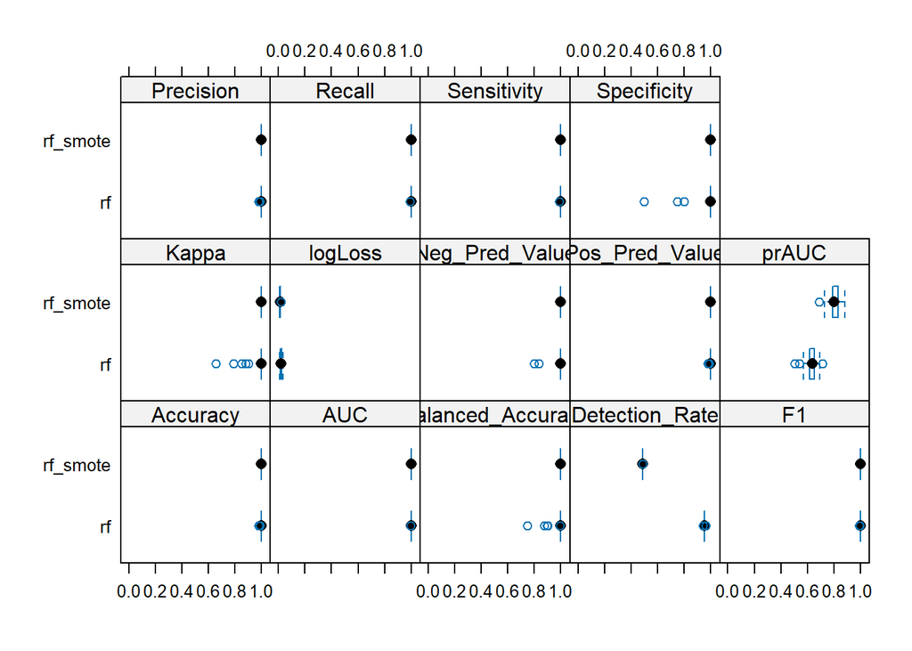

```r
# Boxplot for accuracy comparison
bwplot(results)
```

```r
# Pairwise comparisons
model_differences <- diff(results)
model_differences$statistics
```

```
$Accuracy
$Accuracy$rf.diff.rf_smote

    One Sample t-test

data:  x
t = -5.362, df = 99, p-value = 5.395e-07
alternative hypothesis: true mean is not equal to 0
95 percent confidence interval:
 -0.003346072 -0.001538529
sample estimates:
 mean of x
-0.0024423



$AUC
$AUC$rf.diff.rf_smote

    One Sample t-test

data:  x
t = -1.4214, df = 99, p-value = 0.1583
alternative hypothesis: true mean is not equal to 0
95 percent confidence interval:
 -9.442461e-05  1.560497e-05
sample estimates:
    mean of x
-3.940982e-05



$Balanced_Accuracy
$Balanced_Accuracy$rf.diff.rf_smote

    One Sample t-test

data:  x
t = -4.1945, df = 99, p-value = 5.965e-05
alternative hypothesis: true mean is not equal to 0
```

[output cut: 166 more lines]

```


$Specificity
$Specificity$rf.diff.rf_smote

    One Sample t-test

data:  x
t = -4.0883, df = 99, p-value = 8.851e-05
alternative hypothesis: true mean is not equal to 0
95 percent confidence interval:
 -0.05272976 -0.01827024
sample estimates:
mean of x
  -0.0355
```

## Visualize the confusion matrix tables

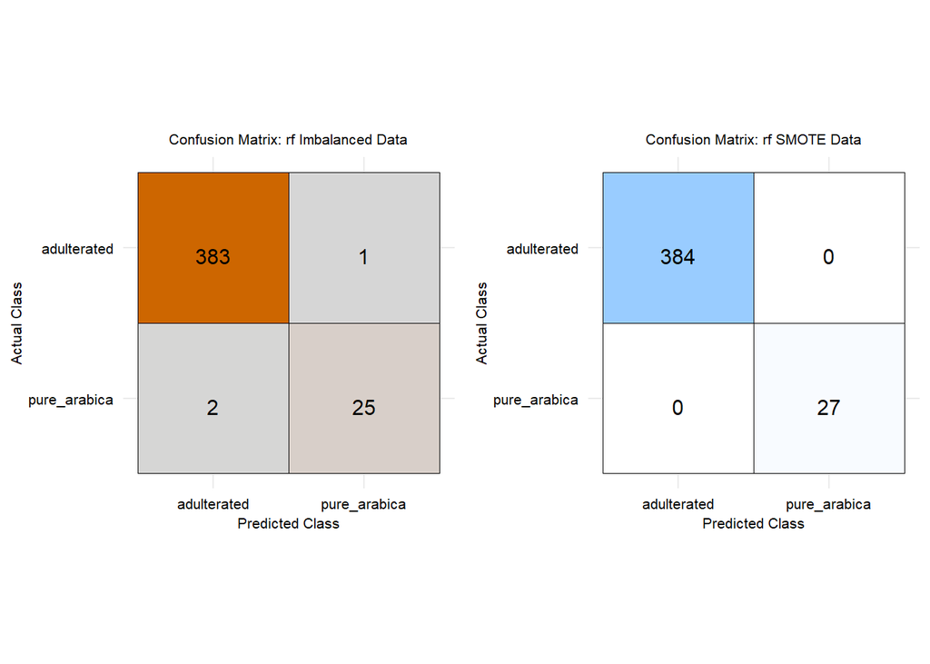

```r
# Imbalanced data
plt_Imb <- as.data.frame(test_rf_unmodified_CMtrx$table)
plt_Imb$Reference <- factor(plt_Imb$Reference, levels=rev(levels(plt_Imb$Reference)))

# SMOTE data
plt_smote <- as.data.frame(test_rf_smote_CMtrx$table)
plt_smote$Reference <- factor(plt_smote$Reference, levels=rev(levels(plt_smote$Reference)))


p1<-ggplot(plt_Imb, aes(y = Reference, x = Prediction, fill=Freq)) +
  geom_tile(aes(fill = Freq), color = "black") +
  geom_text(aes(label=Freq), vjust = 1,color = "black",size = 4) +
  scale_fill_gradient(low = "gray84", high = "darkorange3", name = "Frequency") +
  theme_minimal() +
  labs(x = "Predicted Class", y = "Actual Class", color = 'black',title = 'Confusion Matrix: rf Imbalanced Data')+
  theme(
    legend.position =  "none",
    axis.text.y = element_text(color = "black",size = 8),
    axis.title.x  = element_text(size = 8),
    axis.text.x = element_text(color = "black",size = 8),
    axis.title.y = element_text(size = 8),aspect.ratio = 1,
    plot.title = element_text(size = 8,hjust = 0.5))


p2<-ggplot(plt_smote, aes(y = Reference, x = Prediction, fill=Freq)) +
  geom_tile(aes(fill = Freq), color = "black") +
  geom_text(aes(label=Freq), vjust = 1,color = "black",size = 4) +
  scale_fill_gradient(low = "white", high = "#99ccff", name = "Frequency") +
  theme_minimal() +
  labs(x = "Predicted Class", y = "Actual Class", color = 'black',title = 'Confusion Matrix: rf SMOTE Data')+
  theme(
    legend.position =  "none",
    axis.text.y = element_text(color = "black",size = 8),
    axis.text.x = element_text(color = "black",size = 8),
    axis.title.x  = element_text(size = 8),
    axis.title.y = element_text(size = 8),aspect.ratio = 1,
    plot.title = element_text(size = 8,hjust = 0.5))

grid.arrange(p1,p2, nrow =1)
```

## ROC Curve

```r
#SMOTE data
# Generate the ROC curve
roc_curve <- roc(test_merged_smote_Preprocessed$binary_class,
                 as.numeric(test_rf_smote),
                 levels = c("adulterated", "pure_arabica"),
                 positive = 'adulterated')
```

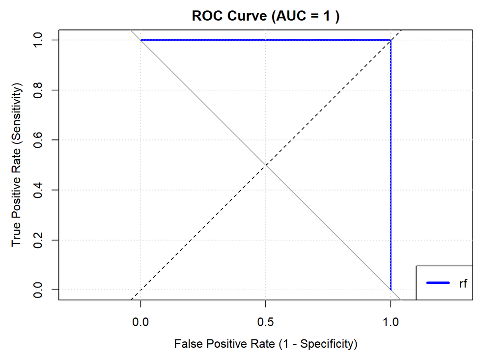

```r
# Calculate the AUC
auc_value <- auc(roc_curve)

# Plot the ROC curve
plot(roc_curve, col = 'blue', lwd = 2,
     main = paste("ROC Curve (AUC =", round(auc_value, 2), ")"),
     xlab = "False Positive Rate (1 - Specificity)",
     ylab = "True Positive Rate (Sensitivity)",
     xlim = c(0, 1), ylim = c(0, 1))
abline(a = 0, b = 1, lty = 2, col = "black")
grid(nx = NULL, ny = NULL, col = "lightgray", lty = "dotted")
legend("bottomright", legend = c("rf"), col = 'blue', lwd = 3)
```

### Misclassifications

```r
## Imbalanced
observed <- y_test
predicted <- test_rf_unmodified
perc <- hsi_msc_sg_2d %>% filter(cal_val==2) %>% dplyr::select(perc_adulter)

imbal_class <- as.data.frame(cbind(observed,predicted,perc))
misclas_imbal <- imbal_class %>% filter(observed!=predicted)
misclas_imbal
```

```
      observed    predicted perc_adulter
1 pure_arabica  adulterated            0
2 pure_arabica  adulterated            0
3  adulterated pure_arabica          100
```

```r
table(misclas_imbal$perc_adulter)
```

```
  0 100
  2   1
```

```r
# SMOTE Data
observed <- y_test
predicted <- test_rf_smote
perc <- hsi_msc_sg_2d %>% filter(cal_val==2) %>% dplyr::select(perc_adulter)

bal_class <- as.data.frame(cbind(observed,predicted,perc))
misclas_smote <- bal_class %>% filter(observed!=predicted)
misclas_smote
```

```
[1] observed     predicted    perc_adulter
<0 rows> (or 0-length row.names)
```

```r
table(misclas_smote$perc_adulter)
```

```
< table of extent 0 >
```